# Homework 2 for Statistical Thinking

Allison Nguyen

2025-01-23

eid: ann2464

github link:https://github.com/05alli/Hw2

# **Problem 1: Beauty, or not, in the classroom**

**Part A**

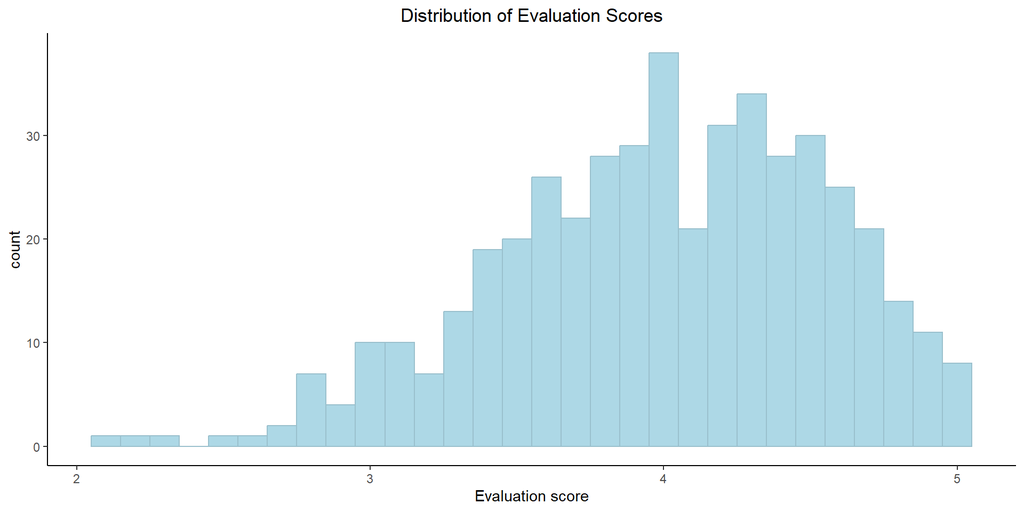

Evaluation scores tend to lean towards the right, 5, with the median score being 4.

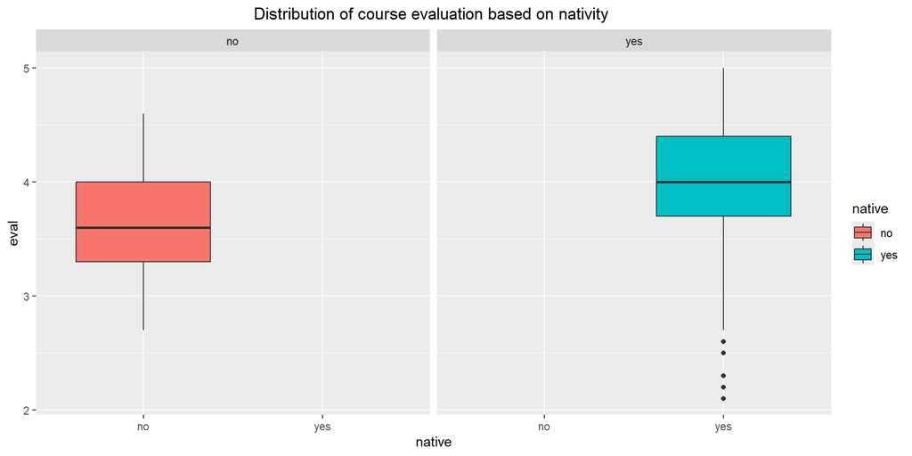

The distribution for non-native speakers is smaller compared to the distribution for native speakers. The median for non-native speakers is 3.6 and the median for native speakers is 4.This demonstrates that native English speakers receive higher scores compared to non-native speakers.

**Part C**

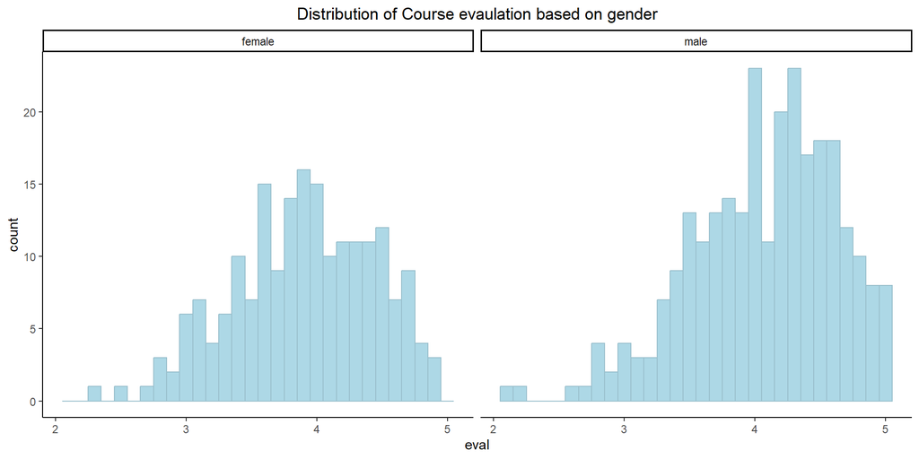

**Part D**

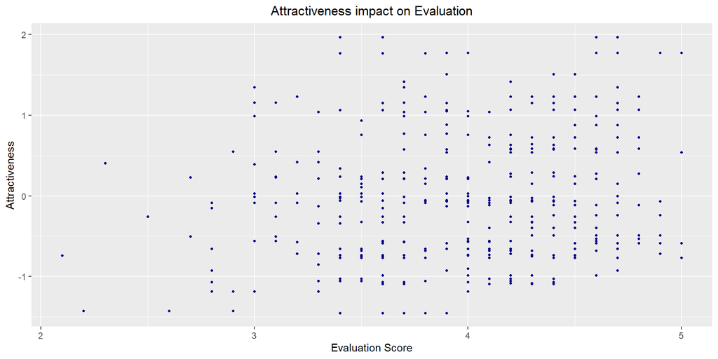

This dot plot demonstrates that there is no strong correlation between the Attractiveness of the professor and the Evaluation Score that they were given by students.

# **Problem 2: bike sharing**

**Plot A**

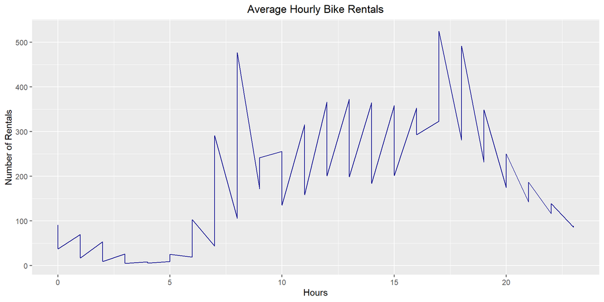

This line graph demonstrates that the hours with the highest average number of bike rentals is 8 am, 5 pm, and 6 pm. In addition, the hours with the lowest average number of bike rentals is 4 and 5 am.

**Plot B**

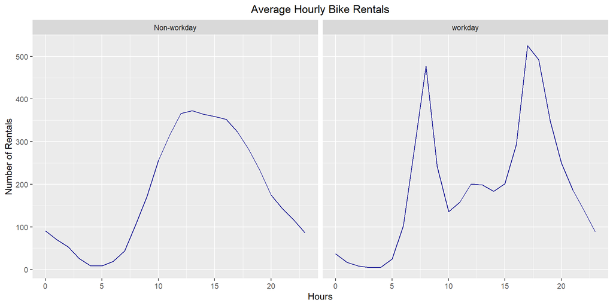

The differences between these two graphs are very striking. The Workday graph follows the work schedule of a 9-5. Around these times are when most bikes are rented presumably by workers who are going to and leaving work. However, the non-workday graph shows the afternoon being the time most bikes are rented. This could be due to most people on their days off going out around the afternoon.

**Plot C**

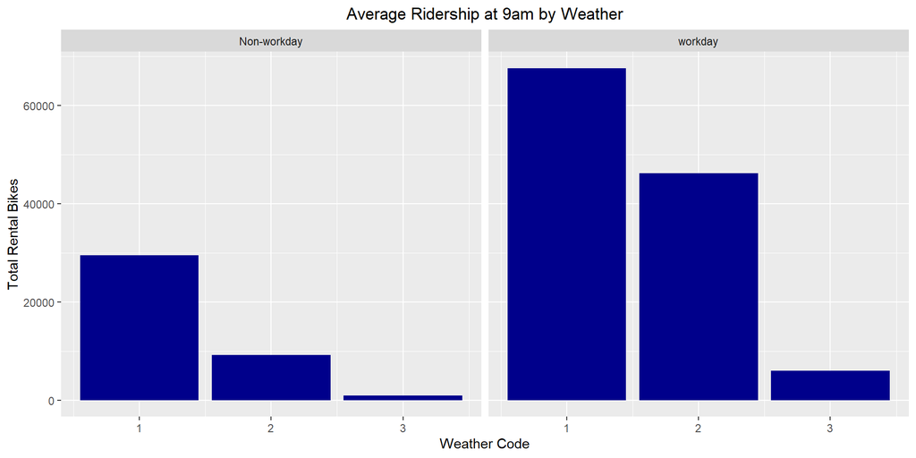

Code 1 means that the weather is clear or partly cloudy, 2 means that there is Mist,3 means that there is light snow, light rain and/or Thunderstorm. The graph shows that whenever the weather gets more serious there tends to be a signifcant drop in bike rentals comapred to when it is partly cloudy or mist. Furthermore, most of the time bikes are rented during workdays.

# **Problem 3 - Capital Metro UT Ridership**

**1.)**

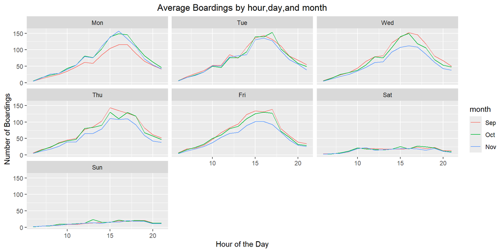

**2.)**

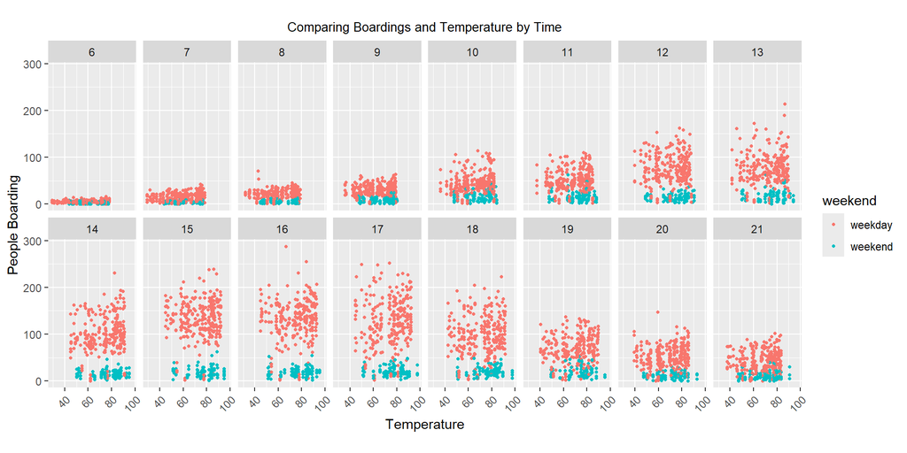

This faceted scatter plot shows bus boarding vs. temperature by hour, with points colored by weekday (red) or weekend (blue). The data suggests temperature has little effect on ridership when controlling for time and weekend status. Boarding patterns remain consistent across temperatures, with weekday afternoons (14:00–18:00) showing the highest ridership regardless of temperature.

# **Problem 4: Wrangling the Billboard Top 100**

**Part A:**

Top 10 Most Popular Songs by weeks on billboard

| performer | song | count |
| --- | --- | --- |
| Imagine Dragons | Radioactive | 87 |
| AWOLNATION | Sail | 79 |
| Jason Mraz | I’m Yours | 76 |
| The Weeknd | Blinding Lights | 76 |
| LeAnn Rimes | How Do I Live | 69 |
| LMFAO Featuring Lauren Bennett & GoonRock | Party Rock Anthem | 68 |
| OneRepublic | Counting Stars | 68 |
| Adele | Rolling In The Deep | 65 |
| Jewel | Foolish Games/You Were Meant For Me | 65 |
| Carrie Underwood | Before He Cheats | 64 |

This table displays the name of the artists, the top 10 songs by number of weeks they were on the billboard, and the total number of weeks that these songs stayed on the billboard.

**Part B:**

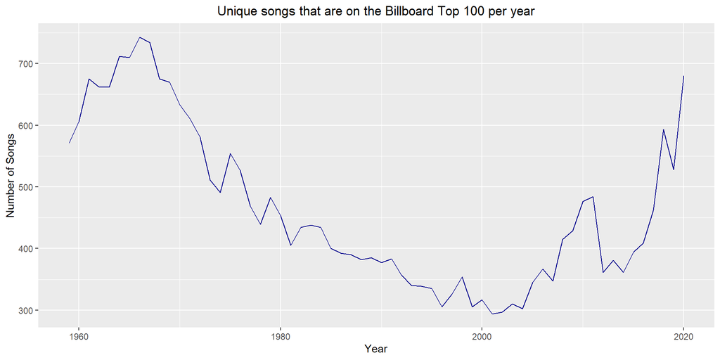

**Part C:**

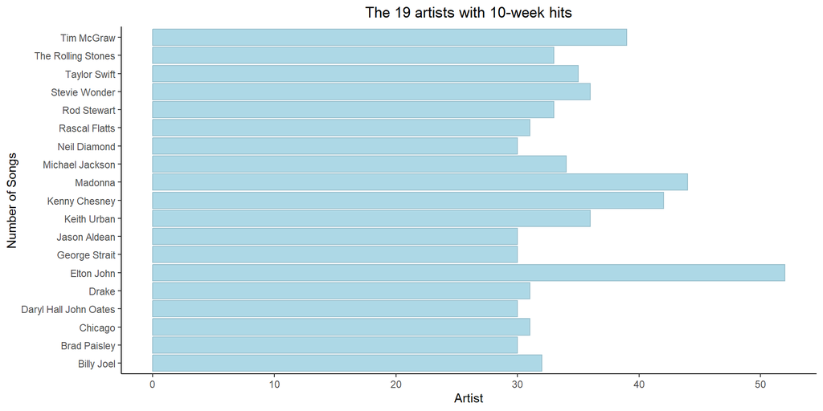

This graph shows how many songs do these 19 artists with 10-week hits have. The person with the most being Elton John with over 50 songs and the person with the least is Neil Diamond, Jason Aldean,George Strait,Daryl Hall John Oates,and Brad Paisley with 30 songs each.